# “gnparser”: a powerful parser for scientific names based on Parsing Expression Grammar

八木浩樹

2019-06-06

# “gnparser”: a powerful parser for scientific names based on Parsing Expression Grammar

- 生物の学名表記には微妙なバリエーションがある
- それらをパースする既存のソフトウェアには速度、正確性などの点で問題がある
- プログラム言語などのパーサーに用いられている技術を使うことで、それらの問題を解決した

# 生物の学名表記

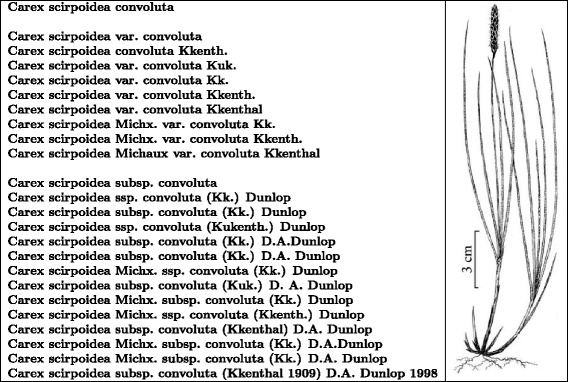

**Carex scirpoidea convoluta**の様々な表記

**様々な表記が同一の種を示している**

# 生物の学名表記

名寄せ(reconciliation)のために、**Carex scirpoidea var. convoluta Kükenthal** という文字列から

- genus: Carex
- species: scirpoidea
- variety: convoluta
- author: Kükenthal

の情報を手にいれるパーサーが必要

# パーサーってなに

- 文章をパースするプログラム
- ↓パース

```
> 今日は良い天気ですね
今日    名詞,副詞可能,*,*,*,*,今日,キョウ,キョー
は      助詞,係助詞,*,*,*,*,は,ハ,ワ
良い    形容詞,自立,*,*,形容詞・アウオ段,基本形,良い,ヨイ,ヨイ
天気    名詞,一般,*,*,*,*,天気,テンキ,テンキ
です    助動詞,*,*,*,特殊・デス,基本形,です,デス,デス
ね      助詞,終助詞,*,*,*,*,ね,ネ,ネ
```

- 自然言語はパースが難しい
- プログラミング言語はパースしやすい(そう作られているため)

```r
quote(3 * 5 + sqrt(3)) %>% as.list %>% str
```

```
## List of 3
##  $ : symbol +
##  $ : language 3 * 5
##  $ : language sqrt(3)
```

## 既存のパーサー1 GBIF Name Parser

- Global Biodiversity Information Facilityが公開しているパーサー
- `http://api.gbif.org/v1/parser/name?name=Carex scirpoidea var. convoluta Kükenthal` のように、URLのパラメーターに文字列を与えることでパースしてくれる
- 正規表現による実装

## 正規表現 (Regular expression)

- 文字列の集合を一つの文字列で表現する方法
- 携帯電話番号(= 文字列の集合)の正規表現(= 文字列) → `[0-9]{3}-[0-9]{4}-[0-9]{4}`
- 主に文字列のマッチングに使われる
- パースのために使おうと思えば使えないこともない

## パースのために使おうと思えば使えないこともない

### 気象庁の天気概要を例に

- https://www.data.jma.go.jp/obd/stats/data/mdrr/man/gaikyo.html
- “晴れ時々曇り後雪、雷を伴う”
- 「基本天気用語」（必須） ＋ 「天気変化用語」（0～3語） ＋ 「伴う現象」（0～1語）

## パースのために使おうと思えば使えないこともない

### 気象庁の天気概要を例に

> (快晴|晴|曇|薄曇|大風|霧|霧雨|雨|大雨|暴風雨|みぞれ|雪|大雪|暴風雪|地ふぶき|ふぶき|ひょう|あられ|雷|×)(?:((一時|時々|後|後一時|後時々)(快晴|晴|曇|薄曇|大風|霧|霧雨|雨|大雨|暴風雨|みぞれ|雪|大雪|暴風雪|地ふぶき|ふぶき|ひょう|あられ|雷|×)){0,3})(?:、(快晴|晴|曇|薄曇|大風|霧|霧雨|雨|大雨|暴風雨|みぞれ|雪|大雪|暴風雪|地ふぶき|ふぶき|ひょう|あられ|雷|×)を伴う)?
- 人間のやることではない
- 再帰構造を表現できないなど、根本的な限界がある
  - 雑種の学名は “学名 × 学名” という再帰構造をもつ

## 既存のパーサー2 biodiversity

- rubyによる生物学名のパーサーライブラリ
  - 文字列処理に強い
  - DSLの充実
- https://github.com/GlobalNamesArchitecture/biodiversity `gem install biodiversity`
- 正規表現ではなくPEGを利用している

## Parsing Expression Grammar (PEG)

- ある形式言語の文法を表現するための手法
- ≒ プログラム言語のパーサーを書くための手法
- 正規表現では表現不可能だった再帰も扱える
- Yacc(Yet Another Compiler Compiler)と似たようなもの

## Parsing Expression Grammar (PEG)

### 気象庁の天気概要を例に

> tenki <- 快晴|晴|曇|薄曇|大風|霧|霧雨|雨|大雨|暴風雨|みぞれ|雪|大雪|暴風雪|地ふぶき|ふぶき|ひょう|あられ|雷|×

> henka <- 一時|時々|後|後一時|後時々

> tenki (henka kihon)* (、kihon を伴う)?
- 上のPEG規則から、パーサーが生成される
- そのパーサーを使うことで、天気概要をパースできる

## gnparser

- Scala言語で実装
  - Javaの上につくられた言語
  - 色んな環境で動かしやすい
  - Javaよりおしゃれ
  - DSLも書きやすい
- biodiversityの問題点
  - rubyによる速度の制約

# 八木の今後について

## サイエンスミュージアムネット

- 日本全国の博物館標本データ
- 解析のために、種名の名寄せ(reconciliation)が必要な場合がある
- ひとまずgnparserをつかいたい

## さらなる展望

- gnparserで対応できない細かい例外
  - アルファベット表記の和名が学名に付属している場合など